# Lab 6

KSRM

## Confidence in Submission

Problem 1: 70 - Worked through Lab 6. I then created the custom function on my own.

## Results of Randomization

In the example data, I selected two vectors with varied distributions to test my custom randomization function. The mean difference of the example groups was approximately 7.67. The result of the randomization test indicates that this mean difference is unlikely to occur by chance alone.

Next, using the intellect ratings for audio and reading groups, the means of these groups were randomized through a monte carlo simulation. The actual mean difference from the data set was approximately 1.98. The results of the randomization test indicate that this mean difference is also unlikely to occur by chance alone. If the observed mean difference had been 0.5, then the data set would have failed the randomization test.

```r
library(dplyr)
```

```r
library(ggplot2)
the_data <- read.csv("open_data/SchroederEpley2015data.csv", header=TRUE)
colnames(the_data)[1] <- gsub('^...', '',colnames(the_data)[1])

group1 <- c(14,16,12,15,13,14) #example data
group2 <- c(3,3,9,10,4,9)

group_size <- length(group1)
mean_difference <- mean(group1)-mean(group2)
print(mean_difference)
```

```
## [1] 7.666667
```

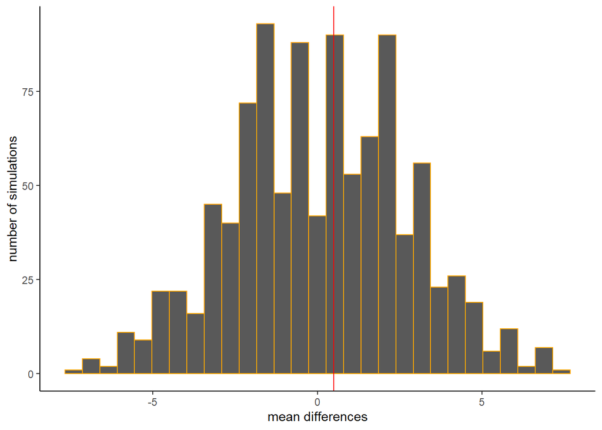

```
## [1] "Probability greater than 0.5 = 0.443"
```

```r
randomization_test <- function (group_1, group_2, n_runs) {
    possible_differences <- c()
    group_size <- length(group_1)
      for (i in 1:n_runs){
        group_means <- c(group_1,group_2) #combining groups
        group_means <- sample(group_means) #shuffling group means
        randomized_group1 <- mean (group_means[1:group_size])
        randomized_group2 <- mean (group_means[(group_size+1):length(group_means)])

    possible_differences[i] <- randomized_group1-randomized_group2 #saving randomized mean differences
      }
    print(qplot(unlist(possible_differences), xlab= "mean differences", ylab="number of simulations")+
      geom_histogram(color = "orange")+
      geom_vline(xintercept = 0.5, color = "red")+
      theme_classic())

    probability <- length(possible_differences[possible_differences>=0.5])/length(possible_differences)
    print(paste("Probability greater than 0.5 =", probability))
}

randomization_test(group1,group2, 1000) #testing custom function
```

```r
random_group1 <- rnorm(100, 0, 1) #second function test
random_group2 <- rnorm(100, 0, 1)
print(mean(random_group1)-mean(random_group2))
```

```
## [1] 0.001317944
```

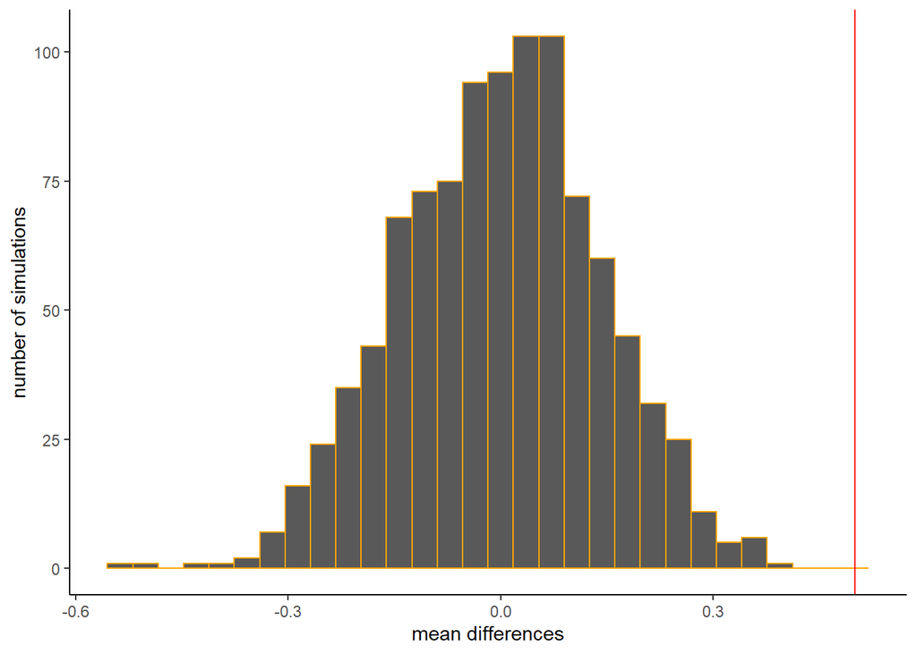

```
## [1] "Probability greater than 0.5 = 0"
```

```r
randomization_test(random_group1,random_group2, 1000)
```

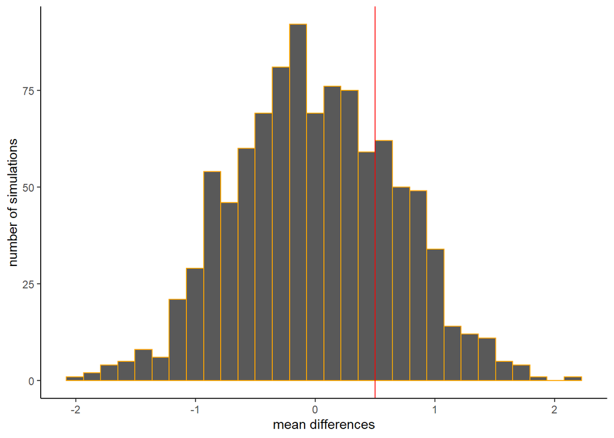

```
## [1] "Probability greater than 0.5 = 0.243"
```

```r
audio_rating <- the_data %>%
  filter(CONDITION==1) %>%
  select(Intellect_Rating)
audio_rating <- as.vector(audio_rating[,"Intellect_Rating"])

reading_rating <- the_data %>%
  filter(CONDITION==0) %>%
  select(Intellect_Rating)
reading_rating <- as.vector(reading_rating[,"Intellect_Rating"])

randomization_test(audio_rating, reading_rating, 1000)
```

```r
experimental <- mean(audio_rating)-mean(reading_rating)
print(experimental) #mean difference
```

```
## [1] 1.986772
```

## For comparison: results of additional randomization based on course lesson

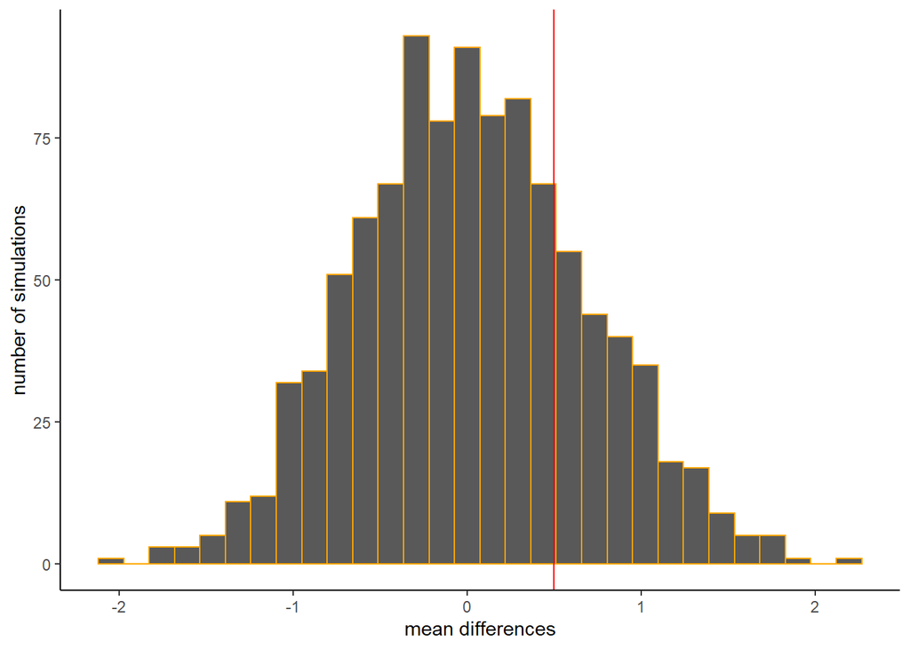

```r
possible_differences <- c()
for (i in 1:1000){
  new_data <- the_data %>%
    mutate(randomizedcondition = sample(CONDITION, 39, replace=TRUE))%>%
    group_by(randomizedcondition)%>%
    summarize(new_mean=mean(Intellect_Rating))
    possible_differences[i] <-new_data[new_data$randomizedcondition==1,]$new_mean-new_data[new_data$randomizedcondition     ==0,]$new_mean
}
qplot(unlist(possible_differences), xlab = "mean differences", ylab = "number of simulations")+
  geom_histogram(color="orange")+
  geom_vline(xintercept=0.5,color="red")+
  theme_classic()
```

```r
length(possible_differences[possible_differences>=0.5])/length(possible_differences)
```

```
## [1] 0.24
```